# BCB420-A2

2023-03-15

## Loading Required Packages

```r
if(! requireNamespace("BiocManager")) install.packages("BiocManager")
if(! requireNamespace("ComplexHeatmap")) BiocManager::install("ComplexHeatmap")
if(! requireNamespace("circlize")) install.packages("circlize")
if(! requireNamespace("gprofiler2")) install.packages("gprofiler2")
if(! requireNamespace("knitr")) install.packages("knitr")
if(! requireNamespace("kableExtra")) install.packages("kableExtra")
if(! requireNamespace("magrittr")) install.packages("magrittr")
if(! requireNamespace("edgeR")) install.packages("edgeR")
```

# Introduction

Here, we perform differential expression analysis and threshold over-representation analysis on an RNAseq dataset (GSE: GSE110649) from the paper “Transcriptional and metabolic rewiring of colorectal cancer cells expressing the oncogenic KRASG13D mutation” (Charitou et al. 2019). Using this dataset, the paper attempts to compare the transcriptome of HKE3, a line of colorectal cancer cells, with mutant and wild type KRAS genes before TGF-alpha treatment and at five different time points after treatment ($t = 15, 30, 60, 90, 120$ minutes).

Prior to this analysis, we first cleaned the data by filtering out genes with low counts per million, removing rows that lacked identifiers and altogether removing duplicate rows except for RNA-8S5, which we merged. After cleaning the dataset, we were left with 16827 rows of 58051 rows originally, i.e. a final coverage of 28.98%. Finally, we normalized the data by using the Trimmed Mean of M-values (TMM) method.

Using the final dataset from A1, we will find which genes are differentially expressed and perform a preliminary analysis to see which genesets and pathways are enriched within these genes.

## Loading the dataset

First, as the experiment performed in the original paper was rather complex, it was suggested to focus on a single aspect of it. In particular, I decided to focus on performing differential expression analysis on the mutant and wild-type cells before TGF$\alpha$ treatment (i.e. t=0). This was chosen as it is one of the main analyses done in the paper, whereas it revealed the pre-existing differences in the transcriptome of colorectal cancer cells HKE3 with mutant vs. wild type KRAS genes.

```r
# Loading the dataset
normalized_count_data <- read.delim("./GSE110649_normalized_data.csv",
                                    sep=",",
                                    check.names=FALSE,
                                    header=TRUE)

# Only keep columns corresponding to t=0
baseline_ind <- grepl("T0", colnames(normalized_count_data))
baseline_counts <- normalized_count_data[,baseline_ind]
rownames(baseline_counts) <- normalized_count_data$Gene
```

# Differential Expression Analysis

## Define Groups

First, we define the groups based on the column names, i.e. whether each column is HKE3-mtKRAS or HKE3-wtKRAS and which replicate it is.

```r
# Separate samples by "_" and keep the first and second indices
samples <- data.frame(lapply(colnames(baseline_counts),
                             FUN=function(x){unlist(strsplit(x,
                                                             split="_"))[c(1,3)]}))

# Replace the column names of "samples" with the actual column names of the data
colnames(samples) <- colnames(baseline_counts)
rownames(samples) <- c("cell_type", "replicate")
samples <- data.frame(t(samples)) # Flip the col and row of the dataframe
```

## Check MDS plots for factors

Next, in order to choose the factors in our model, we look at the MDS plots.

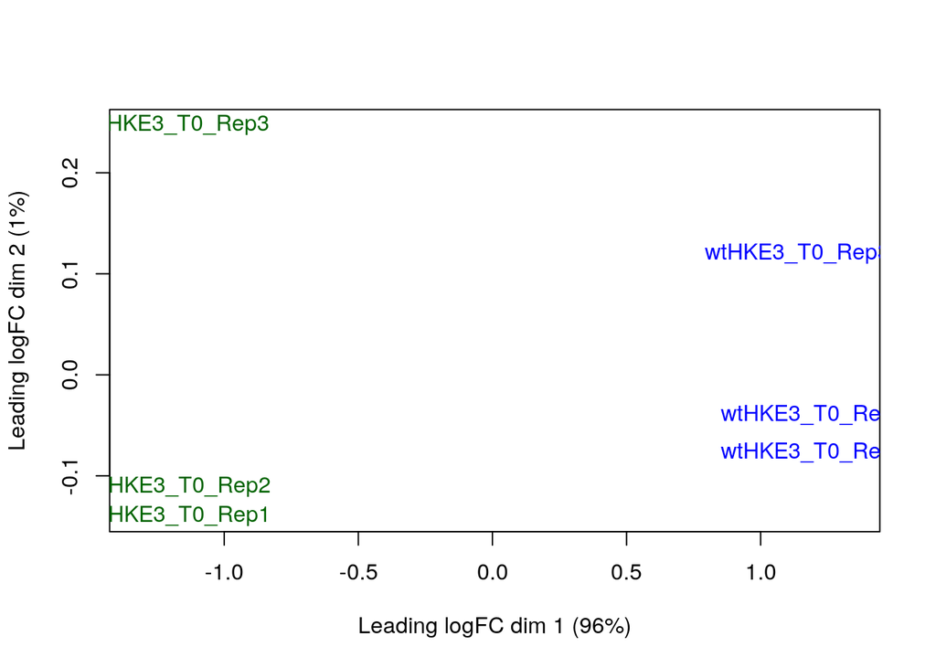

Figure 1. MDS plot of normalized counts of HKE3-mtKRAS and HKE3-wtKRAS cells before treatment (t=0).

```r
library(edgeR)
d = DGEList(counts=as.matrix(baseline_counts), group=samples$cell_type)

plotMDS.DGEList(d, labels=rownames(samples),
               col=c("darkgreen", "blue")[factor(samples$cell_type)])
```

From the MDS plot, we can see that the observations are clustered by cell type, which makes sense in terms of the experiment. Thus, we specify the model based on cell type and fit it.

```r
# Create model
model_design <- model.matrix(~ samples$cell_type) # Create model matrix
d <- estimateDisp(d, model_design) # Estimate dispersion
fit <- glmQLFit(d, model_design) # Fit model
```

Using this fitted model, we test for significance.

```r
qlf.mt_vs_wt <- glmQLFTest(fit, coef="samples$cell_typewtHKE3") # Perform significance test
tt_mt_vs_wt <- topTags(qlf.mt_vs_wt, n=nrow(d)) # Extract top hits from test
top_outputs <- tt_mt_vs_wt$table # Extract results table
```

Finally, we calculate the number of genes with p-values and FDR values which pass the significance threshold.

```r
ind_signif_p <- which(top_outputs$PValue < 0.05) # Get indices of top outputs with p-value < 0.05
ind_signif_fdr <- which(top_outputs$FDR < 0.05) # Get indices of top outputs with FDR < 0.05
num_p <- length(ind_signif_p)
num_fdr <- length(ind_signif_fdr)
```

Moving forward we will use the FDR in our work.

## Volcano Plot

In order to summarize our analysis, we demonstrate it in a volcano plot, as shown above. Here, we highlight genes of interest, i.e. those with FDR $< 0.05$ and absolute $log_2$ fold change greater than 1.5, as upregulated or downregulated based on the sign of their $log_2$ fold change.

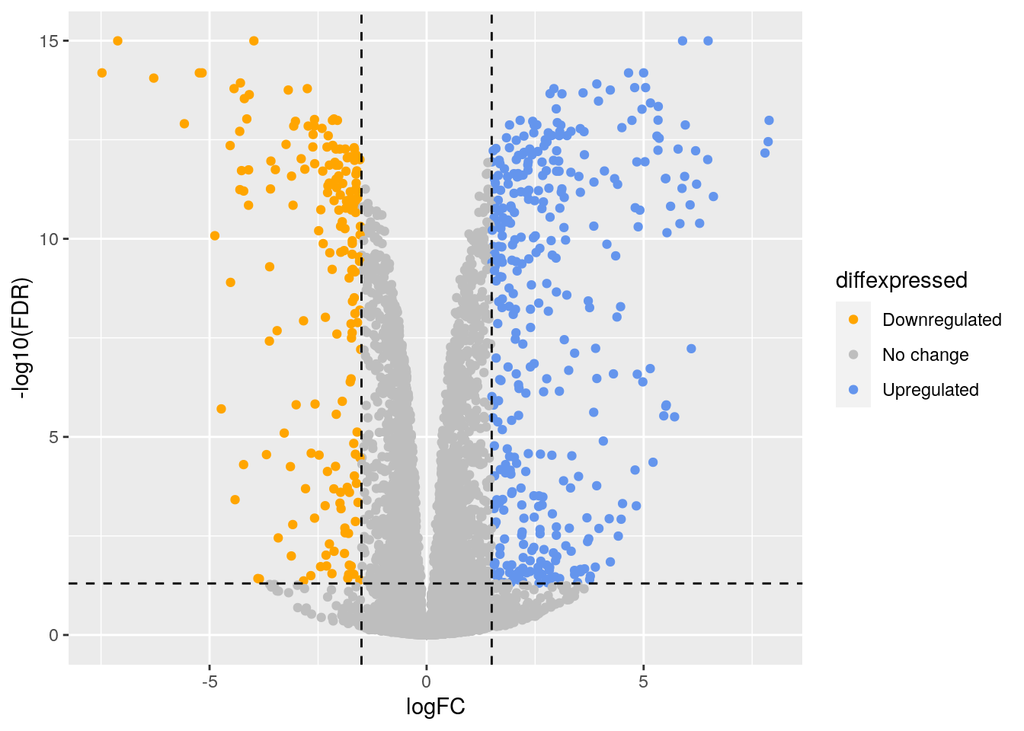

Figure 2. Volcano plot of the top hits from the differential expression analysis of HKE3-mtKRAS to HKE3-wtKRAS cells before TGF-alpha treatment.

```r
# Label top hits with whether its been significantly upregulated/downregulated or there's no change
top_outputs$diffexpressed <- "No change"
top_outputs$diffexpressed[which(top_outputs$logFC > 1.5 & top_outputs$FDR < 0.05)] <- "Upregulated"
top_outputs$diffexpressed[which(top_outputs$logFC < -1.5 & top_outputs$FDR < 0.05)] <- "Downregulated"

cols <- rep("grey", nrow(top_outputs))
cols[which(top_outputs$logFC > 1.5 & top_outputs$FDR < 0.05)] <- "cornflowerblue"
cols[which(top_outputs$logFC < -1.5 & top_outputs$FDR < 0.05)] <- "orange"

library(ggplot2)

ggplot(data = top_outputs, aes(x=logFC, y=-log10(FDR), col=diffexpressed)) +
  geom_point() +
  scale_color_manual(values=c("orange", "grey", "cornflowerblue")) +
  geom_hline(yintercept=-log10(0.05), col="black", lty=2) + # Add horizontal line a FDR = 0.05
  geom_vline(xintercept=c(-1.5, 1.5), col="black", lty=2) # Add vertical line at abs(logFC) > 1.5
```

## Heatmap

Finally, we create a heatmap to demonstrate the scaled differences in the normalized RNA counts of the top hits.

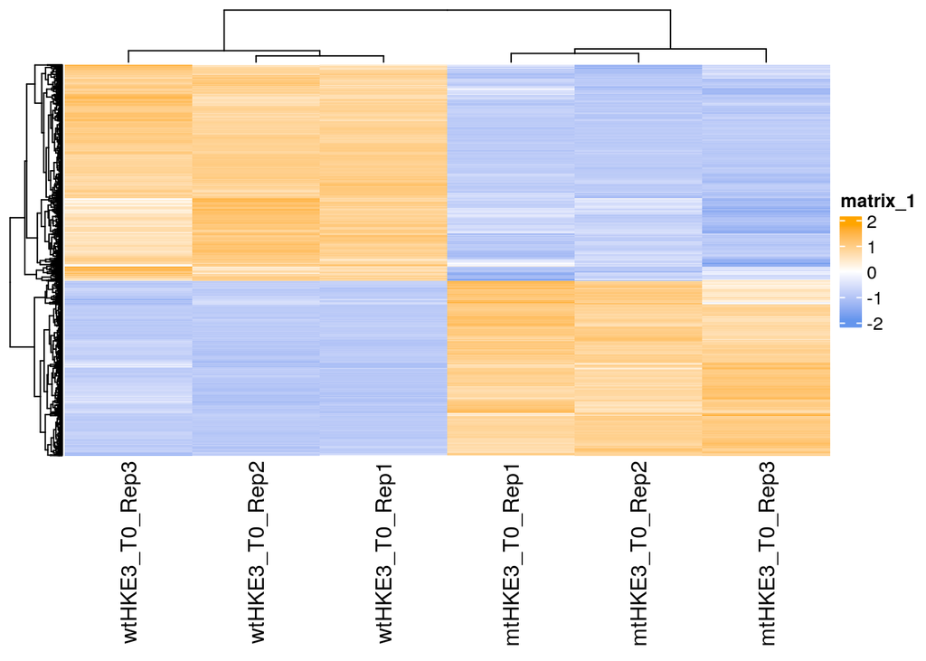

Figure 3. Heatmap of the scaled normalized RNA counts of the top hits found through differential expressions analysis of HKE3-mtKRAS to HKE3-wtKRAS cells before TGF-alpha treatment.

```r
signif_genes <- rownames(top_outputs)[ind_signif_fdr] # Get names of significant genes
signif_baseline_ind <- which(rownames(baseline_counts) %in% signif_genes) # Get indices of significant genes in counts data

# Scale the data
scaled_hits_heatmap_matrix <- t(
  scale(t(as.matrix(baseline_counts[signif_baseline_ind,]))))

library(circlize)

# Create the colorscales based on if there are negative scaled count values
if(min(scaled_hits_heatmap_matrix) < 0){
  colscale <- colorRamp2(c(min(scaled_hits_heatmap_matrix), 0, max(scaled_hits_heatmap_matrix)),
                           c("cornflowerblue", "white", "orange"))
} else {
  colscale <- colorRamp2(c(min(scaled_hits_heatmap_matrix), max(scaled_hits_heatmap_matrix)),
                           c("white", "orange"))
}

library(ComplexHeatmap)

# Create heatmap
Heatmap(scaled_hits_heatmap_matrix,
        cluster_rows = TRUE,
        cluster_columns = TRUE,
        show_row_dend=TRUE,
        col = colscale,
        show_column_names = TRUE,
        show_row_names = FALSE,
        show_heatmap_legend=TRUE)
```

## Question 1

Here, we chose to use the standard significance threshold of $\alpha = 0.05$. We see that 4061 genes were significantly differentially expressed (i.e. their p-values were less than $0.05$).

## Question 2

We use the false discovery rate (FDR) to correct for multiple hypotheses. We chose to use the FDR because firstly it is a less than stringent correction than Bonferroni’s correction, thus allowing us to capture a larger set of significant genes. Next, we use FDR for convenience, as that is the default value of the edgeR `glmQLFTest()` function. Using the same standard significance threshold, we find that 2911 genes are significantly differentially expressed when considering the FDR.

## Question 4

We display the original scaled normalized count data in a heatmap. Here, we see that the conditions cluster together. This makes sense because we only use one condition (HKE3-wtKRAS vs HKE3-mtKRAS) with biological replicates. Thus, it is to be expected that they will have similar transcriptomes save for some biological variation, and thus they will cluster together. Further, there seems to be a striking difference between the expression of the top hits between the two conditions, which nicely supports the validaty of our differential expression analysis process.

# Thresholded List

We first create the threshholded lists based on a FDR $< 0.01$ and whether the log fold change was greater than or else than zero, as well as the whole list.

```r
# Get indices of significant upregulated and downregulated
up_ind <- which(tt_mt_vs_wt$table$FDR < 0.01 & tt_mt_vs_wt$table$logFC > 0)
down_ind <- which(tt_mt_vs_wt$table$FDR < 0.01 & tt_mt_vs_wt$table$logFC < 0)

# Get gene names of upregulated genes
upreg <- tt_mt_vs_wt$table[up_ind,]
upreg_list <- rownames(upreg)

# Get gene names of downregulated genes
downreg <- tt_mt_vs_wt$table[down_ind,]
downreg_list <- rownames(downreg)
```

Next, we run the thresholded over-representation analysis using g:Profiler on the upregulated and downregulated thresholded lists. Using this, we can then find the number of pathways/gene sets found in each query.

```r
library(gprofiler2)

# Query gprofiler for upregulated list
gostres_up <- gost(query = upreg_list,
                organism = "hsapiens", significant = FALSE, exclude_iea = TRUE,
                correction_method = "fdr",
                domain_scope = "annotated",
                numeric_ns = "", sources = c("GO:BP", "REAC", "WP"))

# Query gprofiler for downregulated list
gostres_down <- gost(query = downreg_list,
                organism = "hsapiens", significant = FALSE, exclude_iea = TRUE,
                correction_method = "fdr",
                domain_scope = "annotated",
                numeric_ns = "", sources = c("GO:BP", "REAC", "WP"))

# Query gprofiler for whole list
gostres <-  gost(query = c(upreg_list, downreg_list),
                organism = "hsapiens", significant = FALSE, exclude_iea = TRUE,
                correction_method = "fdr",
                domain_scope = "annotated",
                numeric_ns = "", sources = c("GO:BP", "REAC", "WP"))

num_genesets_up <- nrow(gostres_up$result)
num_genesets_down <- nrow(gostres_down$result)
num_genesets_all <- nrow(gostres$result)
```

Next we filtered out terms that were too general and might obscure important pathways by only taking those with term size less than or equal to 200.

```r
# Filter for terms with term_size <= 200
filtered_gos_up <- gostres_up$result[which(gostres_up$result$term_size <= 200),]
filtered_gos_down <- gostres_down$result[which(gostres_down$result$term_size <= 200),]
filtered_gos <- gostres$result[which(gostres$result$term_size <= 200),]
```

```r
library(magrittr)
library(kableExtra)

filtered_gos_up[1:12,c("term_name", "p_value")] %>%
  kbl(caption="Table 1. Top filtered pathways hits for significantly upregulated wtKRAS genes.", row.names = FALSE, digits = 32) %>%
  kable_styling()
```

Table 1. Top filtered pathways hits for significantly upregulated wtKRAS genes.

| term_name | p_value |
| --- | --- |
| negative regulation of viral process | 1.478586e-11 |
| regulation of viral life cycle | 8.703165e-11 |
| regulation of viral process | 1.783198e-10 |
| negative regulation of viral genome replication | 3.884870e-10 |
| antigen processing and presentation of peptide antigen via MHC class I | 1.070167e-09 |
| positive regulation of I-kappaB kinase/NF-kappaB signaling | 1.644228e-08 |
| regulation of viral genome replication | 2.320226e-08 |
| cellular response to type I interferon | 3.453087e-08 |
| antigen processing and presentation of peptide antigen | 4.327385e-08 |
| antigen processing and presentation of endogenous peptide antigen | 6.399368e-08 |
| viral genome replication | 1.028714e-07 |
| interferon-mediated signaling pathway | 1.406723e-07 |

```r
filtered_gos_down[1:12,c("term_name", "p_value")] %>%
  kbl(caption="Table 2. Top filtered pathways hits for significantly downregulated wtKRAS genes.", row.names = FALSE, digits = 52) %>%
  kable_styling()
```

Table 2. Top filtered pathways hits for significantly downregulated wtKRAS genes.

| term_name | p_value |
| --- | --- |
| cytoplasmic translation | 1.990550e-41 |
| sterol biosynthetic process | 9.749386e-10 |
| secondary alcohol biosynthetic process | 1.739181e-09 |
| cholesterol biosynthetic process | 1.739181e-09 |
| positive regulation of protein localization to nucleus | 4.280445e-07 |
| regulation of protein localization to nucleus | 1.508574e-06 |
| cholesterol metabolic process | 2.746673e-06 |
| pyruvate metabolic process | 5.486116e-06 |
| positive regulation of establishment of protein localization to telomere | 6.708879e-06 |
| regulation of ubiquitin protein ligase activity | 9.595469e-06 |
| secondary alcohol metabolic process | 1.222779e-05 |
| regulation of establishment of protein localization to telomere | 1.530565e-05 |

```r
filtered_gos[1:12, c("term_name", "p_value")] %>%
  kbl(caption="Table 3. Top filtered pathways hits for differentially expressed wtKRAS genes.", row.names = FALSE, digits = 32) %>%
  kable_styling()
```

Table 3. Top filtered pathways hits for differentially expressed wtKRAS genes.

| term_name | p_value |
| --- | --- |
| cytoplasmic translation | 3.604902e-23 |
| regulation of viral process | 1.316401e-09 |
| regulation of viral life cycle | 5.846908e-09 |
| actomyosin structure organization | 1.463721e-08 |
| negative regulation of viral process | 1.568092e-08 |
| skin development | 7.454652e-08 |
| cell-matrix adhesion | 8.962507e-08 |
| endothelial cell migration | 1.725242e-07 |
| negative regulation of viral genome replication | 2.807013e-07 |
| positive regulation of protein localization to nucleus | 6.545142e-07 |
| regulation of cell-substrate adhesion | 8.921949e-07 |
| antigen processing and presentation of peptide antigen via MHC class I | 1.197610e-06 |

## Question 1

We ran a threshold gene set enrichment analysis on the top hits. In particular, we decided to use the R package version of g:Profiler. This is primarily because of pre-existing familiarity with the interface and process.

## Question 2

In terms of data sources, we use GO biological process, Reactome, and WikiPathways, since we are interested in the biological pathways and processes that these genes may be enriched in. Further, we exclude electronic GO annotations, as we would like high quality annotations, as discussed in class.

# Interpretation

## Question 1

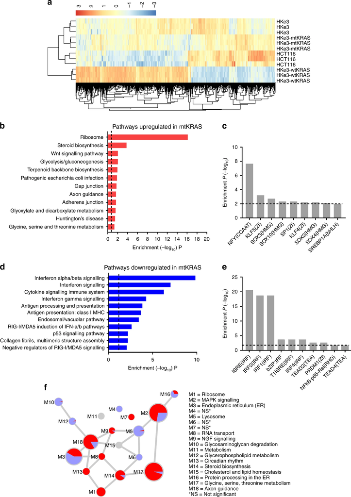

Figure 4. Figure 2 from the paper “Transcriptional and metabolic rewiring of colorectal cancer cells expressing the oncogenic KRASG13D mutation” (Charitou et al. 2019).

## Question 2

Finally, there is literature to support the results seen. First, looking at the pathways which are significantly upregulated in wtKRAS, we find that most if not all are related to the immune system (specifically antigens and interferon related pathways). Those that involve viruses can similarly be related to immune system pathways as they involve the regulation of these through the immune system. In addition, there is literature support that suggests that oncogenic mtKRAS is connected with inflammation and immune system modulation, leading to the creation of an environment in which tumours can grow and cancer cells may escape the body’s immune response (Pereira et al. 2022). Thus, based on this evidence, it may be reasonable to say that wtKRAS will be upregulated in these pathways as compared to wtKRAS.

Next, looking at significantly downregulated pathways in wtKRAS, these include various metabolic processes such as sterol, cholesterol, and pyruvate. This is supported by the paper, “KRAS-Driven Metabolic Rewiring Reveals Novel Actionable Targets in Cancer” (Pupo et al. 2019), which suggests that oncogenic mtKRAS is involved in the shifting of metabolism to anabolic processes in order to support cancer cell proliferation. This includes the break down of fats (i.e. sterols and cholesterol metabolism from the above analysis), as well as the synthesis of nucleotides, which requires pyruvates. Thus, as this suggests that these pathways may be upregulated in oncogenic mtKRAS as opposed to wtKRAS, they are downregulated in wtKRAs as opposed to oncogenic mtKRAS.

Finally, the top hit of our threshold overrepresentation analysis for downregulation was cytoplasmic translation. This is also supported by literature evidence, which suggests that oncogenic mtKRAS will deregulate the PI3K/PDK1 RAS effector pathway which is involved in translation, cell growth, and proliferation (Jancı́k et al. 2010). Thus, it is unsurprising that in our results, cytoplasmic translation is downregulated in wtKRAS as opposed to mtKRAS.

# References

Charitou, Theodosia, Sriganesh Srihari, Miriam A Lynn, Mohamed-Ali Jarboui, Erik Fasterius, Max Moldovan, Senji Shirasawa, et al. 2019. “Transcriptional and Metabolic Rewiring of Colorectal Cancer Cells Expressing the Oncogenic KRASG13D Mutation.” *Br. J. Cancer* 121 (1): 37–50.

Jancı́k, Sylwia, Jirı́ Drábek, Danuta Radzioch, and Marián Hajdúch. 2010. “Clinical Relevance of KRAS in Human Cancers.” *J. Biomed. Biotechnol.* 2010 (June): 150960.

Pereira, Flávia, Anabela Ferreira, Celso Albuquerque Reis, Maria João Sousa, Maria José Oliveira, and Ana Preto. 2022. “KRAS as a Modulator of the Inflammatory Tumor Microenvironment: Therapeutic Implications.” *Cells* 11 (3): 398.

Pupo, Emanuela, Daniele Avanzato, Emanuele Middonti, Federico Bussolino, and Letizia Lanzetti. 2019. “KRAS-driven Metabolic Rewiring Reveals Novel Actionable Targets in Cancer.” *Front. Oncol.* 9 (August): 848.